# Featurizing Full Medical History for Modelling

Published

November 25, 2026

We have the history of when which ICD codes were assigned to each patient, so we can featurize this time series to get the following sets of values per patient.

## Describe Basic Feature of Medical History

Here the “history” is every time they were assigned a unique ICD code on a specific date, so a 2-column tibble with the columns `encounter_date` and `ICD_code`. We can compute the “cumulative” ICD code set at each point in time, either total codes assigned or total unique codes assigned. So with this cumulative code counts (total or unique) we can compute several features per patient “summarizing” their history.

- `history_metric`: wheter metric is calculated with total or unique code counts
- `n_codes`: number of codes assigned over total history
- `n_visits`: number of unique visits
- `history_length`: medical history length in real-time (days)
- `mean_codes_per_visit`: n_codes / n_visits
- `code_frequency`: n_codes / history_length
- `normalized_mean_time`: see linked notes below
- `KS_vs_uniform`: see linked notes below
- `shannon_entropy`: see linked notes below
- `burstiness`: see linked notes below

There are some more basic features like “length”, “total nunber of codes” etc. which can calibrate our “confidence”/data richness per patient and more “shape-like” features that have richer interpretations, see further notes [here](https://docs.google.com/document/d/1cLN_i3Gwpaw1JAnrSIQBvaNd5htuucYVKfBv-OQY-Oc/edit?usp=sharing)

## Plotting History-derived Features

Now we can load the shape features derived from each patient’s code history across all patients

```r
all_medical_history_shape_features_df <-
    load_all_patient_history_features(force_redo=FALSE)
```

```
0.355 sec elapsed
```

```r
all_medical_history_shape_features_df %>%
    head() %>%
    kable()
```

| FID | history_metric | n_codes | n_visits | mean_codes_per_visit | history_length | code_frequency | normalized_mean_time | KS_vs_uniform | shannon_entropy | burstiness |
| --- | --- | --- | --- | --- | --- | --- | --- | --- | --- | --- |
| SINAI-Million_1105332_2132469751 | total_codes | 1682 | 449 | 3.7461024 | 6089 | 0.2762358 | 0.6715709 | 0.2404660 | 0.9535981 | -0.1239722 |
| SINAI-Million_1105332_2132469751 | unique_codes | 153 | 449 | 0.3407572 | 6089 | 0.0251273 | 0.6589248 | 0.2708150 | NA | 0.4105991 |
| SINAI-Million_193941_3536477784 | total_codes | 505 | 46 | 10.9782609 | 4895 | 0.1031665 | 0.8072827 | 0.6197299 | 0.8900706 | -0.1129311 |
| SINAI-Million_193941_3536477784 | unique_codes | 71 | 46 | 1.5434783 | 4895 | 0.0145046 | 0.6852376 | 0.4632384 | NA | 0.1699906 |
| SINAI-Million_P61659021_2132515715 | total_codes | 2060 | 204 | 10.0980392 | 5151 | 0.3999223 | 0.7352480 | 0.4211635 | 0.9175869 | -0.0389161 |
| SINAI-Million_P61659021_2132515715 | unique_codes | 152 | 204 | 0.7450980 | 5151 | 0.0295088 | 0.5897184 | 0.1972995 | NA | 0.2861558 |

Now we can plot the “basic” features and the more “complex” features

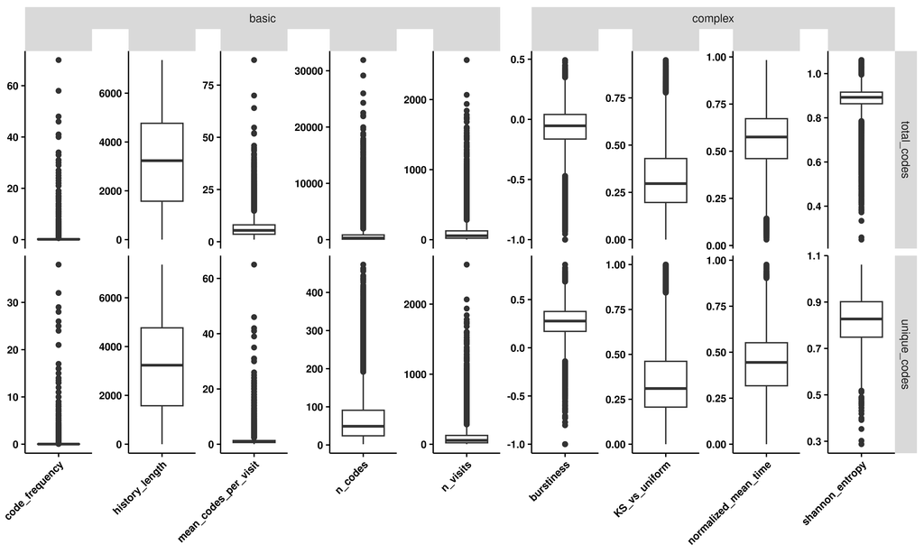

```r
all_medical_history_shape_features_df %>%
    pivot_longer(
        -c(FID, history_metric),
        names_to='history_shape_feature',
        values_to='value'
    ) %>%
    # filter(history_shape_feature %notin% c('mean_codes_per_visit')) %>%
    mutate(
        complexity=
            case_when(
                history_shape_feature %in%
                    c(
                        'normalized_mean_time',
                        'KS_vs_uniform',
                        'shannon_entropy',
                        'burstiness'
                    ) ~ 'complex',
                .default='basic'
            )
    ) %>%
    {
        ggplot(
            data=.,
            mapping=
                aes(
                    x=history_shape_feature,
                    y=value
                )
        ) +
        geom_boxplot() +
        ggh4x::facet_nested(
            rows = vars(history_metric),
            cols = vars(complexity, history_shape_feature),
            scales = 'free',
            independent = 'y',
            strip =
                ggh4x::strip_nested(
                    by_layer_x = TRUE,
                    text_x =
                        list(
                            ggplot2::element_text(),  # outer
                            ggplot2::element_blank()  # inner
                        )
                )
        ) +
        make_ggtheme() +
        theme(
            legend.position='top',
            axis.title=element_blank(),
            axis.text.x=element_text(angle=45, hjust=1, vjust=1)
        )
    }
```